# $\color{purple}{\text{FOMC Statements (2007-2022):}}$

#### UNRATE

This model explains the FOMC statement sentiment score in terms of the U-3 measure of labor unemployment as published monthly by the Bureau of Labor Statistics (BLS). For this financial variable, we use a backward difference of 1 lag - `bd1`.

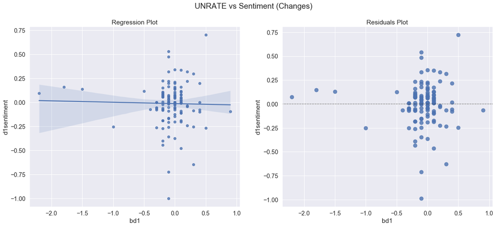

```python
plot_unrate_bd1()
```

```python
print(mod_fit_UNRATE_bd1.summary())
```

```
                            OLS Regression Results
==============================================================================
Dep. Variable:            d1sentiment   R-squared:                       0.001
Model:                            OLS   Adj. R-squared:                 -0.008
Method:                 Least Squares   F-statistic:                   0.06733
Date:                Thu, 19 May 2022   Prob (F-statistic):              0.796
Time:                        21:35:08   Log-Likelihood:                 13.414
No. Observations:                 125   AIC:                            -22.83
Df Residuals:                     123   BIC:                            -17.17
Df Model:                           1
Covariance Type:            nonrobust
==============================================================================
                 coef    std err          t      P>|t|      [0.025      0.975]
------------------------------------------------------------------------------
const         -0.0116      0.020     -0.583      0.561      -0.051       0.028
bd1           -0.0144      0.056     -0.259      0.796      -0.124       0.095
==============================================================================
Omnibus:                       32.409   Durbin-Watson:                   2.318
Prob(Omnibus):                  0.000   Jarque-Bera (JB):              113.684
Skew:                          -0.848   Prob(JB):                     2.06e-25
Kurtosis:                       7.354   Cond. No.                         2.85
==============================================================================

Notes:
[1] Standard Errors assume that the covariance matrix of the errors is correctly specified.
```

#### PCEPILFE

This model explains the FOMC statement sentiment score in terms of the Personal Consumption Expenditures Excluding Food and Energy. For this financial variable, we use a backward proportional change of 12 months - `bp12`.

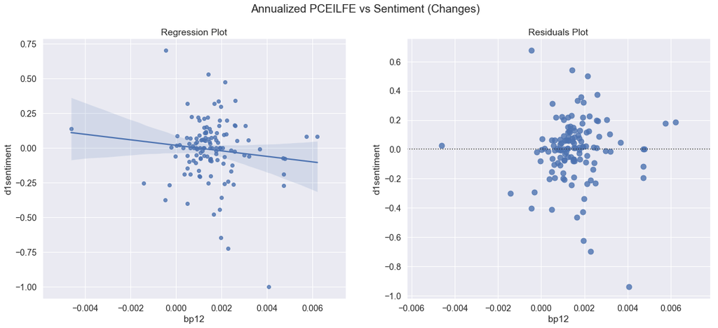

```python
plot_pce_bd1()
```

```python
print(mod_fit_PCEPILFE_bp12.summary())
```

```
                            OLS Regression Results
==============================================================================
Dep. Variable:            d1sentiment   R-squared:                       0.014
Model:                            OLS   Adj. R-squared:                  0.006
Method:                 Least Squares   F-statistic:                     1.739
Date:                Thu, 19 May 2022   Prob (F-statistic):              0.190
Time:                        21:35:08   Log-Likelihood:                 14.257
No. Observations:                 125   AIC:                            -24.51
Df Residuals:                     123   BIC:                            -18.86
Df Model:                           1
Covariance Type:            nonrobust
==============================================================================
                 coef    std err          t      P>|t|      [0.025      0.975]
------------------------------------------------------------------------------
const          0.0200      0.030      0.659      0.511      -0.040       0.080
bp12         -19.8883     15.081     -1.319      0.190     -49.740       9.963
==============================================================================
Omnibus:                       28.254   Durbin-Watson:                   2.380
Prob(Omnibus):                  0.000   Jarque-Bera (JB):               81.991
Skew:                          -0.790   Prob(JB):                     1.57e-18
Kurtosis:                       6.640   Cond. No.                         775.
==============================================================================

Notes:
[1] Standard Errors assume that the covariance matrix of the errors is correctly specified.
```

### Financial Market Variables

Date Alignment for financial model fit: for each FOMC date $f(i)$, we find the financial variable for the date. Most variables are available daily. We estimate a model on the change in the financial variable as a result of the change in sentiment.

One important problem is that FOMC statement is released during the market hours at 2pm EST. Thus, the financial variable recorded at end of day on the same day as the FOMC statement already reflects the sentiment impact. Therefore, we need to compare the change in response of the financial variable across a date before the FOMC statement versus 1 or more days after the FOMC statement.

#### BAA10Y

This model explains the Moody's Seasoned Baa Corporate Bond yield relative to yield on 10-year Treasury Constant Maturities in terms of the the sentiment score.

#### Two-Day Difference (fp2)

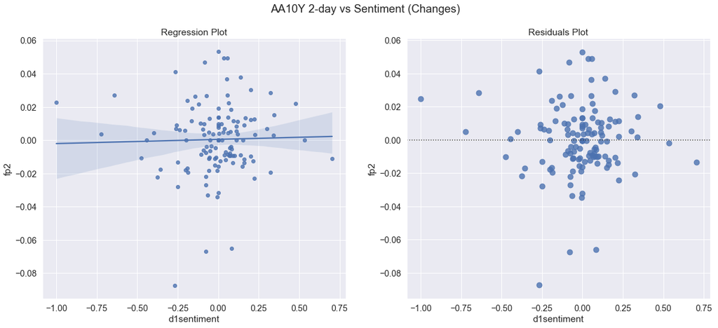

```python
plot_BAA10Y_fp2()
```

```python
print(mod_fit_BAA10Y_fp2.summary())
```

```
                            OLS Regression Results
==============================================================================
Dep. Variable:                    fp2   R-squared:                       0.001
Model:                            OLS   Adj. R-squared:                 -0.007
Method:                 Least Squares   F-statistic:                   0.08551
Date:                Thu, 19 May 2022   Prob (F-statistic):              0.770
Time:                        21:35:09   Log-Likelihood:                 306.50
No. Observations:                 125   AIC:                            -609.0
Df Residuals:                     123   BIC:                            -603.3
Df Model:                           1
Covariance Type:            nonrobust
===============================================================================
                  coef    std err          t      P>|t|      [0.025      0.975]
-------------------------------------------------------------------------------
const           0.0005      0.002      0.261      0.794      -0.003       0.004
d1sentiment     0.0025      0.009      0.292      0.770      -0.015       0.020
==============================================================================
Omnibus:                       20.689   Durbin-Watson:                   1.979
Prob(Omnibus):                  0.000   Jarque-Bera (JB):               52.712
Skew:                          -0.586   Prob(JB):                     3.58e-12
Kurtosis:                       5.958   Cond. No.                         4.60
==============================================================================

Notes:
[1] Standard Errors assume that the covariance matrix of the errors is correctly specified.
```

#### T10YIE

This model explains the breakeven inflation rate in terms of the the sentiment score.

#### Two-Day Difference (fp2)

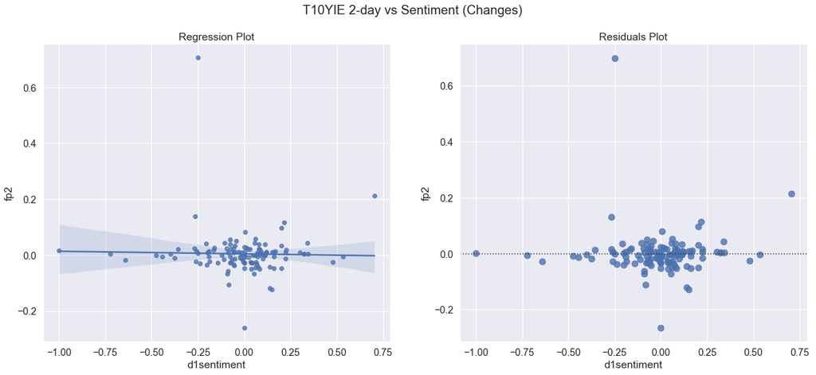

```python
plot_T10YIE_fp2()
```

```python
print(mod_fit_T10YIE_fp2.summary())
```

```
                            OLS Regression Results
==============================================================================
Dep. Variable:                    fp2   R-squared:                       0.001
Model:                            OLS   Adj. R-squared:                 -0.007
Method:                 Least Squares   F-statistic:                   0.08128
Date:                Thu, 19 May 2022   Prob (F-statistic):              0.776
Time:                        21:35:10   Log-Likelihood:                 140.28
No. Observations:                 125   AIC:                            -276.6
Df Residuals:                     123   BIC:                            -270.9
Df Model:                           1
Covariance Type:            nonrobust
===============================================================================
                  coef    std err          t      P>|t|      [0.025      0.975]
-------------------------------------------------------------------------------
const           0.0047      0.007      0.664      0.508      -0.009       0.019
d1sentiment    -0.0093      0.033     -0.285      0.776      -0.074       0.055
==============================================================================
Omnibus:                      180.644   Durbin-Watson:                   1.324
Prob(Omnibus):                  0.000   Jarque-Bera (JB):            12758.556
Skew:                           5.409   Prob(JB):                         0.00
Kurtosis:                      51.297   Cond. No.                         4.60
==============================================================================

Notes:
[1] Standard Errors assume that the covariance matrix of the errors is correctly specified.
```

#### WILL5000IND

This model explains the total returns of the Wilshire 5000 Stock Index in terms of the the sentiment score.

#### Two-Day Difference (fp2)

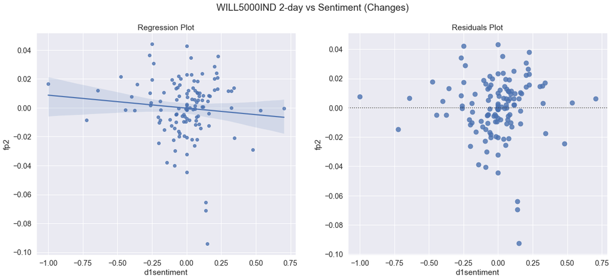

```python
plot_WILL5000IND_fp2()
```

```python
print(mod_fit_WILL5000IND_fp2.summary())
```

```
                            OLS Regression Results
==============================================================================
Dep. Variable:                    fp2   R-squared:                       0.009
Model:                            OLS   Adj. R-squared:                  0.001
Method:                 Least Squares   F-statistic:                     1.126
Date:                Thu, 19 May 2022   Prob (F-statistic):              0.291
Time:                        21:35:10   Log-Likelihood:                 308.91
No. Observations:                 125   AIC:                            -613.8
Df Residuals:                     123   BIC:                            -608.2
Df Model:                           1
Covariance Type:            nonrobust
===============================================================================
                  coef    std err          t      P>|t|      [0.025      0.975]
-------------------------------------------------------------------------------
const          -0.0003      0.002     -0.137      0.892      -0.004       0.003
d1sentiment    -0.0090      0.008     -1.061      0.291      -0.026       0.008
==============================================================================
Omnibus:                       39.021   Durbin-Watson:                   2.347
Prob(Omnibus):                  0.000   Jarque-Bera (JB):               98.687
Skew:                          -1.203   Prob(JB):                     3.72e-22
Kurtosis:                       6.628   Cond. No.                         4.60
==============================================================================

Notes:
[1] Standard Errors assume that the covariance matrix of the errors is correctly specified.
```

#### DGS10

This model explains the yield on 10-year Treasury Constant Maturities in terms of the the sentiment score.

#### Two-Day Difference (fp2)

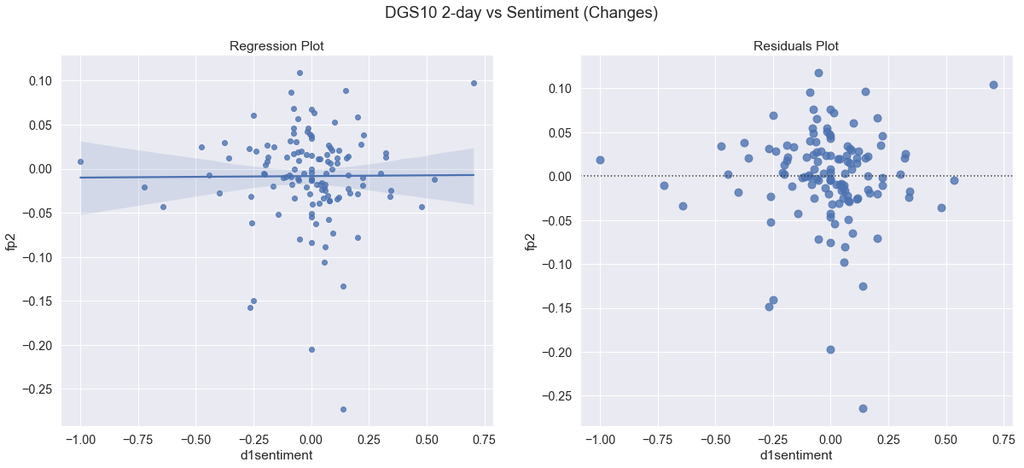

```python
plot_DGS10_fp2()
```

```python
print(mod_fit_DGS10_fp2.summary())
```

```
                            OLS Regression Results
==============================================================================
Dep. Variable:                    fp2   R-squared:                       0.000
Model:                            OLS   Adj. R-squared:                 -0.008
Method:                 Least Squares   F-statistic:                  0.006063
Date:                Thu, 19 May 2022   Prob (F-statistic):              0.938
Time:                        21:35:11   Log-Likelihood:                 189.57
No. Observations:                 125   AIC:                            -375.1
Df Residuals:                     123   BIC:                            -369.5
Df Model:                           1
Covariance Type:            nonrobust
===============================================================================
                  coef    std err          t      P>|t|      [0.025      0.975]
-------------------------------------------------------------------------------
const          -0.0084      0.005     -1.747      0.083      -0.018       0.001
d1sentiment     0.0017      0.022      0.078      0.938      -0.042       0.045
==============================================================================
Omnibus:                       56.039   Durbin-Watson:                   2.057
Prob(Omnibus):                  0.000   Jarque-Bera (JB):              214.422
Skew:                          -1.575   Prob(JB):                     2.75e-47
Kurtosis:                       8.590   Cond. No.                         4.60
==============================================================================

Notes:
[1] Standard Errors assume that the covariance matrix of the errors is correctly specified.
```

### Evaluation

We construct a summary table of the resulting $R^2$, independent variable coefficient, and corresponding P-value. None of the models are statistically significant to consider the macroeconomic variables capable of predicting the FOMC sentiment score, nor to consider the FOMC sentiment score capable of predicting financial market variables across a multiple-day horizon.

```python
model_results_df.style.set_table_styles(dfstyle)
```

|  | Model | R-squared | Variable Coefficient | Variable Coefficient P-value |
| --- | --- | --- | --- | --- |
| 0 | CIVPART_bd1 | 0.006066 | 0.101714 | 0.387942 |
| 1 | UNRATE_bd1 | 0.000547 | -0.014406 | 0.795701 |
| 2 | PCEPILFE_bp12 | 0.013943 | -19.888330 | 0.189691 |
| 3 | BAA10Y_fp2 | 0.000695 | 0.002527 | 0.770454 |
| 4 | BAA10Y_fp5 | 0.001123 | 0.005838 | 0.711816 |
| 5 | T10YIE_fp2 | 0.000660 | -0.009314 | 0.776044 |
| 6 | T10YIE_fp5 | 0.000015 | -0.001824 | 0.965658 |
| 7 | WILL5000IND_fp2 | 0.009072 | -0.008996 | 0.290706 |
| 8 | WILL5000IND_fp5 | 0.010089 | -0.012839 | 0.267008 |
| 9 | DGS10_fp2 | 0.000049 | 0.001715 | 0.938063 |
| 10 | DGS10_fp5 | 0.004739 | -0.036081 | 0.447410 |

### $\color{green}{\text{4.4 - Discussion}}$

The Loughran-McDonald dictionary for financial sentiment in the `PySentiment` library produces a plausible measure of sentiment called polarity. This measure outperforms the other algorithms implemented in the Python libraries `NLTK`, `TextBlob`, and `Flair`.

When we regress macroeconomic conditions or financial asset returns on changes in sentiment, the linear regression coefficients are not statistically significant. The FOMC statement follows a formulaic approach with boilerplate language and contains tempered language. Market participants find the subtle changes in the text offer significant guidance on monetary policy and investment consequences.

However, the effects of FOMC statements on financial asset prices are usually measured in minutes not days from the time of their release.

[figure not shown]

Source: Rossa (2013)

In contrast, the effects of macroeconomic indicators on FOMC sentiment appear to have the correct sign even if the statistical significance is weak.

- A 1-month decline in Labor Force Participation Rate (`CIVPART`) is associated with a subsequent decline in the next FOMC statement sentiment.
- A 1-month increase in the U3 unemployment rate (`UNRATE`) is associated with a subsequent decline in the next FOMC statement sentiment.
- A 1-month increase in Personal Consumption Expenditures (`PCEPILFE`) is associated with a subsequent decline in the next FOMC statement sentiment.

## $\color{blue}{\text{5 - Conclusion}}$

FOMC members are aware of the Committee's impact on the US economy and global markets through public communications and well as its implemented monetary policy. FOMC statements express sentiment through their measured used of language.

- Through the use of LDA we are able to detect topics that align with periods of quantitative easing. When we examine the time variation in topic weights, weights appear to follow a 0-1 step function rather showing a fractional value.
- We find strong agreement between the start of each QE program to the inception of a new LDA topic.
- We speculate that the change may occur because the FOMC is seeking to justify and explain the QE program to its reading audience in new language.
- The end of a QE program can be harder to detect possibly because the central bank has less urgency to signal the end to the market than the beginning.

FOMC statements also express sentiment that can be measured using the Loughran-McDonald financial dictionary.

- We find the `Pysentiment` polarity measure works well. It produces sentiment changes consistent with the 2008 and 2020 recession.
- Other sentiment algorithms such as `Flair`, `TextBlob` and `NLTK` Vader are inconsistent with the recent recessions.
- Multi-day regression of financial asset returns versus sentiment changes between FOMC meetings are not statistical significant. This is consistent with but contrary to the statistical patterns of intraday price returns versus FOMC announcement releases. We speculate that much of the FOMC price impact is realized within the first 1-2 hours for stocks, Treasuries and credit spreads and undetectable at 2-5 day horizons.

Topic Modeling and sentiment analysis of FOMC statements may not delivery unexpected insights on monetary policy or asset returns. However, they quantify the important aspects of these texts that are usually evaluated subjectively by a human analyst. That may be a valuable complement to the reading audience of FOMC statements.

## $\color{blue}{\text{6 - References}}$

Carlo Rossa, 2013. **"The Financial Market Effect of FOMC Minutes"** Economic Policy Review, Vol. 19, No. 2, 2013 (https://papers.ssrn.com/sol3/papers.cfm?abstract_id=2378398)

Gu, Chen & Kurov, Alexander & Wolfe, Marketa Halova, 2018. **"Relief Rallies after FOMC Announcements as a Resolution of Uncertainty,"** Journal of Empirical Finance, Elsevier, vol. 49(C), pages 1-18.

David O. Lucca & Francesco Trebbi, 2009. **"Measuring Central Bank Communication: An Automated Approach with Application to FOMC Statements,"** NBER Working Papers 15367, National Bureau of Economic Research, Inc. (https://www.nber.org/papers/w15367)

A Cieslak, A Morse, A Vissing-Jorgensen, 2019. **"Stock returns over the FOMC cycle"**, Journal of Finance 74(5), 2201-2248 (https://drive.google.com/file/d/1wpT8A2IpMYBP1ytt8n9mk9AdBsnfQ0Ps/view)

Cannon, S. (2015). **Sentiment of the FOMC: Unscripted.** Economic Review-Federal Reserve Bank of Kansas City, 5. (https://www.kansascityfed.org/documents/545/2015-Sentiment%20of%20the%20FOMC:%20Unscripted.pdf)

Gutierrez, L. F., Siami-Namini, S., Tavakoli, N., & Namin, A. S. (2020, December). **A Concern Analysis of Federal Reserve Statements: The Great Recession vs. The COVID-19 Pandemic.** In 2020 IEEE International Conference on Big Data (Big Data) (pp. 2079-2086). IEEE. (https://arxiv.org/pdf/2012.02098.pdf

Laganà, D. M. (2020). **Federal reserve’s communication: a latent dirichlet allocation analysis with application to FOMC minutes.** (http://tesi.luiss.it/27972/1/713391_LAGANA%27_DAISY%20MARTINA.pdf)

Jegadeesh, N., & Wu, D. (2017). **Deciphering Fedspeak: The information content of FOMC meetings.** SSRN (https://www.aeaweb.org/conference/2016/retrieve.php?pdfid=21466&tk=niAkBk3N)

## $\color{blue}{\text{7 - Appendices}}$

## Technical Appendix

The data table for the QE program topics in the LDA model is shown below.

```python
with pd.option_context('display.max_rows' , 200 ):
    print(topic_weights_hist )
```

```
                 QE3       QE1       QE4       QE2   QE-HALT
date
2007-01-31  0.000000  0.000000  0.000000  0.970152  0.000000
2007-03-21  0.000000  0.000000  0.000000  0.969345  0.000000
2007-05-09  0.000000  0.000000  0.000000  0.970305  0.000000
2007-06-28  0.000000  0.000000  0.000000  0.971399  0.000000
2007-08-07  0.000000  0.000000  0.000000  0.973179  0.000000
2007-09-18  0.000000  0.975816  0.000000  0.000000  0.000000
2007-10-31  0.000000  0.978990  0.000000  0.000000  0.000000
2007-12-11  0.000000  0.976799  0.000000  0.000000  0.000000
2008-01-22  0.000000  0.974007  0.000000  0.000000  0.000000
2008-01-30  0.000000  0.976185  0.000000  0.000000  0.000000
2008-03-18  0.000000  0.979066  0.000000  0.000000  0.000000
2008-04-30  0.000000  0.979544  0.000000  0.000000  0.000000
2008-06-25  0.000000  0.977396  0.000000  0.000000  0.000000
2008-08-05  0.000000  0.976586  0.000000  0.000000  0.000000
2008-09-16  0.000000  0.976182  0.000000  0.000000  0.000000
2008-10-08  0.000000  0.974893  0.000000  0.000000  0.000000
2008-10-29  0.000000  0.978381  0.000000  0.000000  0.000000
2008-12-16  0.000000  0.980489  0.000000  0.000000  0.000000
2009-01-28  0.000000  0.982448  0.000000  0.000000  0.000000
2009-03-18  0.000000  0.981512  0.000000  0.000000  0.000000
2009-04-29  0.000000  0.983436  0.000000  0.000000  0.000000
2009-06-24  0.000000  0.983147  0.000000  0.000000  0.000000
2009-08-12  0.000000  0.983592  0.000000  0.000000  0.000000
2009-09-23  0.000000  0.983860  0.000000  0.000000  0.000000
2009-11-04  0.000000  0.984272  0.000000  0.000000  0.000000
2009-12-16  0.000000  0.981405  0.000000  0.000000  0.000000
2010-01-27  0.000000  0.981297  0.000000  0.000000  0.000000
2010-03-16  0.000000  0.983166  0.000000  0.000000  0.000000
2010-04-28  0.000000  0.982334  0.000000  0.000000  0.000000
2010-06-23  0.000000  0.982566  0.000000  0.000000  0.000000
2010-08-10  0.000000  0.983176  0.000000  0.000000  0.000000
2010-09-21  0.000000  0.983104  0.000000  0.000000  0.000000
2010-11-03  0.285514  0.703665  0.000000  0.000000  0.000000
2010-12-14  0.273790  0.715164  0.000000  0.000000  0.000000
2011-01-26  0.000000  0.659298  0.000000  0.328754  0.000000
2011-03-15  0.000000  0.480299  0.000000  0.507219  0.000000
2011-04-27  0.000000  0.437783  0.000000  0.549659  0.000000
2011-06-22  0.000000  0.000000  0.000000  0.982922  0.000000
```

[output cut: 73 more lines]

```
2020-07-29  0.000000  0.000000  0.982383  0.000000  0.000000
2020-09-16  0.000000  0.000000  0.982985  0.000000  0.000000
2020-11-05  0.000000  0.000000  0.982789  0.000000  0.000000
2020-12-16  0.000000  0.000000  0.982986  0.000000  0.000000
2021-01-27  0.000000  0.000000  0.983190  0.000000  0.000000
2021-03-17  0.000000  0.000000  0.982911  0.000000  0.000000
2021-04-28  0.000000  0.000000  0.982723  0.000000  0.000000
2021-06-16  0.000000  0.000000  0.982135  0.000000  0.000000
2021-07-28  0.000000  0.000000  0.981903  0.000000  0.000000
2021-09-22  0.000000  0.000000  0.982513  0.000000  0.000000
2021-11-03  0.000000  0.000000  0.982540  0.000000  0.000000
2021-12-15  0.000000  0.000000  0.981966  0.000000  0.000000
2022-01-26  0.000000  0.000000  0.981441  0.000000  0.000000
2022-03-16  0.000000  0.000000  0.979462  0.000000  0.000000
2022-05-04  0.000000  0.000000  0.979194  0.000000  0.000000
```